# index.Rmd

Daniel Choi & Renae Wong

5/20/2021

## Introduction

The COVID-19 Pandemic has changed many things. Due to the pandemic, many people have died, lost their jobs, and have been restricted from communicating and interacting in-person. We as a group wanted to explore what the specific aftermaths were of these issues. By analyzing and researching in depth of the relations of adversity the majority of people faced, we came to the conclusion of using this [dataset](https://www.kaggle.com/ayushggarg/covid19-vaccine-adverse-reactions?fbclid=IwAR2aQKWsmC7TMTk3TJ-hVX0Hnpl-ajPINOqKOU5wcDmxsgx8EeQXzIQ8smw).

## Summary

In this data set, we hope to explore the different ways people were affected by COVID-19, by their location, gender, age, and number of days until they experienced adverse effects due to the COVID-19 or the COVID-19 vaccine. From this data set we were able to discover that there were 8755 males and 24468 females, with the average age in the data set being 51. In this dataset, there were 35 features and 34121 participants.

## Table

This table below shows us the gender of participants in each state, and the average age of each participant. We included this table as it reveals the sex, location, and the average age, which allows us to answer our question of research “Which age groups and genders were most impacted by COVID-19, and in which locations were they located in?” Through this table, we were able to gain further insight towards how our participants were impacted due to the COVID pandemic. I used the summarize function to find the sum of the male, female, and unknown genders. I also used the summarize function to find the average of each age. This table is ordered in the highest to lowest average age recorded.

| State | Males | Females | Unknown | Average Age |
| --- | --- | --- | --- | --- |
| GU | 4 | 3 | 0 | 73.00000 |
| WV | 69 | 149 | 2 | 60.21698 |
| WY | 16 | 37 | 0 | 59.52941 |
| VI | 0 | 4 | 0 | 59.50000 |
| LA | 93 | 220 | 4 | 59.23390 |
| FL | 484 | 1146 | 24 | 58.78755 |
| FM | 0 | 1 | 0 | 58.00000 |
| NE | 79 | 182 | 2 | 56.52964 |
| DE | 18 | 45 | 3 | 56.03333 |
| Ca | 0 | 1 | 0 | 56.00000 |
| AK | 42 | 120 | 5 | 55.75625 |
| KY | 118 | 313 | 12 | 55.70188 |
| SD | 33 | 80 | 3 | 55.44248 |
| NC | 194 | 545 | 13 | 55.32847 |
| ND | 22 | 77 | 2 | 55.31633 |
| MN | 173 | 425 | 6 | 54.31126 |
| SC | 69 | 209 | 8 | 54.05098 |
| HI | 44 | 89 | 1 | 53.95238 |
| MD | 175 | 507 | 11 | 53.82047 |
| AL | 81 | 208 | 6 | 53.71481 |
| AR | 60 | 203 | 3 | 53.53815 |
| MI | 226 | 689 | 6 | 53.02189 |
| TN | 107 | 404 | 15 | 52.93265 |
| OH | 243 | 795 | 34 | 52.86978 |
| GA | 168 | 452 | 8 | 52.42906 |
| WI | 158 | 487 | 4 | 52.37553 |
| OK | 93 | 233 | 7 | 52.35256 |
| MS | 41 | 102 | 7 | 52.01471 |
| XB | 0 | 1 | 0 | 52.00000 |
| AZ | 187 | 461 | 11 | 51.69917 |
| NH | 46 | 156 | 1 | 51.66000 |
| CA | 677 | 1837 | 63 | 51.61348 |
| WA | 134 | 491 | 5 | 51.05509 |
| IA | 75 | 258 | 3 | 50.98871 |
| IL | 302 | 814 | 19 | 50.55076 |
| NY | 427 | 1319 | 37 | 50.31429 |
| NJ | 224 | 598 | 14 | 50.20595 |
|  | 1717 | 3457 | 397 | 50.13862 |
| MO | 122 | 429 | 5 | 50.11597 |
| CO | 128 | 481 | 8 | 50.05254 |
| RI | 20 | 88 | 4 | 49.73333 |
| MP | 1 | 2 | 0 | 49.66667 |
| PA | 206 | 781 | 25 | 49.51037 |
| NV | 49 | 147 | 1 | 49.39362 |
| TX | 422 | 1359 | 26 | 49.29049 |
| MA | 174 | 634 | 34 | 49.18084 |
| PR | 44 | 149 | 2 | 49.07772 |
| AS | 0 | 3 | 0 | 49.00000 |
| CT | 109 | 413 | 2 | 48.92623 |
| NM | 65 | 160 | 4 | 48.91163 |
| KS | 78 | 213 | 4 | 48.79505 |
| VT | 17 | 85 | 3 | 48.40385 |
| VA | 161 | 541 | 25 | 48.40267 |
| IN | 278 | 858 | 6 | 48.28135 |
| MT | 67 | 190 | 5 | 48.23137 |
| DC | 16 | 39 | 0 | 48.11321 |
| ME | 44 | 190 | 1 | 47.60000 |
| ID | 32 | 125 | 0 | 47.55844 |
| OR | 72 | 287 | 4 | 46.18261 |
| UT | 50 | 176 | 3 | 45.87273 |
| MH | 1 | 0 | 0 | NaN |

$$\\[.1in]$$

# Charts

$$\\[.1in]$$

## Chart 1

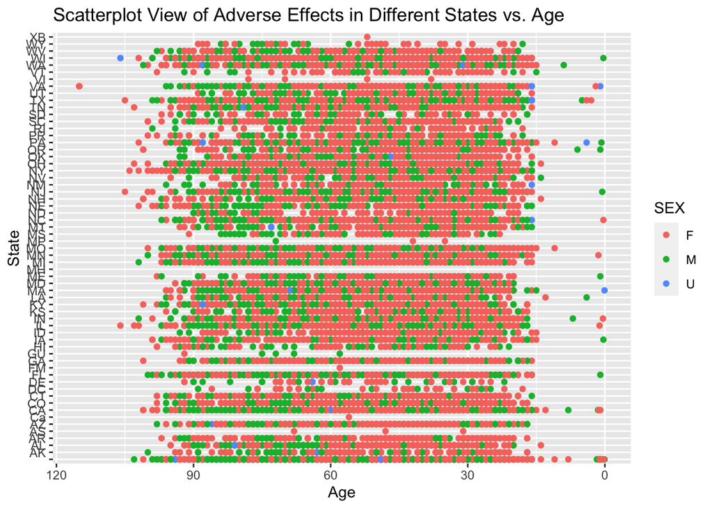

We used a scatter plot to measure the adverse effects of the COVID-19 for each state and separated the data to consider the gender of the participants and the age, where the red signifies the female, green signifies the male, and blue signifies the unknown gender. We included this chart in an attempt to seek the difference age, gender, or location would seem to have on people of the respective pool of research. This information/the chart itself reveals a scatter plot where each dot represents a single participant. Through this, we were able to answer our question of “How has COVID-19 impacted the people of different genders, location, and age.”

$$\\[.1in]$$

## Chart 2

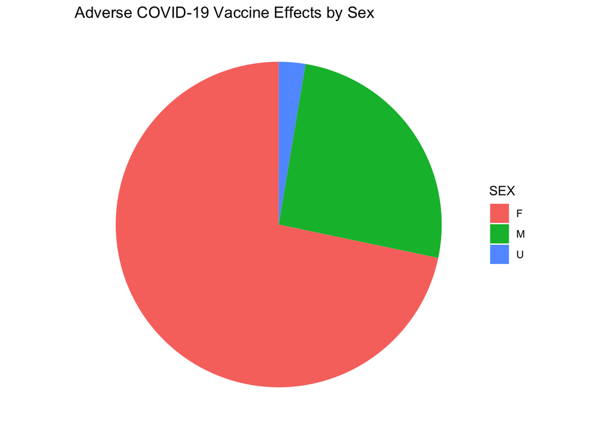

For Chart 2, we attempted to give the visual distribution of gender alone. We wanted to create a chart that would allow us and the users of this information to be given a clear and concise visual that would allow them to understand the overall distribution of males, females, and unknown genders that were recorded into the data set. We seeked to express our question of “What genders were included in this data set, and what was the general distribution of each gender?” The chart itself is a pie chart which reveals the distribution of each gender.

$$\\[.1in]$$

## Chart 3

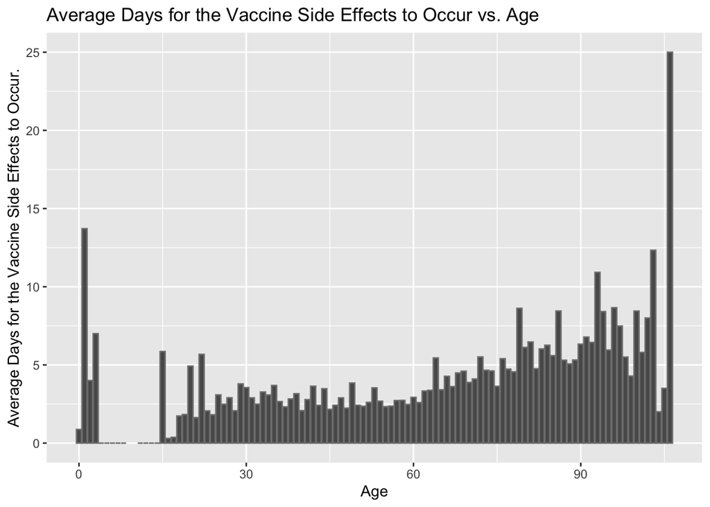

$$\\[.1in]$$